# **Exploration Data Analysis**

```python
import pandas as pd
import numpy as np
import matplotlib.pyplot as plt
import seaborn as sns
```

Importiamo le librerie:

> pandas: dataframe e series numpy: lavorare con gli array matplotlib & seaborn: visualizzazione del dato

##### Da una vista in SQL abbiamo creato una nuova tabella con i dati che occorrono per fare esplorazione del dato

**Lettura del file .csv

```python
df = pd.read_csv("exploration.csv",delimiter=';',header=0)
```

Con la funzione **head()**, visualizziamo i **primi 5 record del dataset**

```python
df.head()
```

|  | GSP0001 | F | 14 | 2023 | ETNA | AQUILA | UCCELLI | In Ottima Salute |
| --- | --- | --- | --- | --- | --- | --- | --- | --- |
| 0 | GSP0002 | M | 2 | 2023 | ETNA | AQUILA | UCCELLI | In Buona Salute |
| 1 | GSP0003 | M | 3 | 2023 | ADDA NORD | AQUILA | UCCELLI | In Ottima Salute |
| 2 | GSP0004 | F | 2 | 2023 | PREALPI GIULIE | AQUILA | UCCELLI | In Ottima Salute |
| 3 | GSP0005 | F | 14 | 2023 | ALPI APUANE | AQUILA | UCCELLI | In Buona Salute |
| 4 | GSP0006 | M | 16 | 2023 | ALPI LIGURI | AQUILA | UCCELLI | In Buona Salute |

**!!ATTENZIONE!!** Da una prima analisi, le colonne sono sprovviste di un header. Provvediamo a dare un nome della colonne!

```python
df.columns=['IDAnimale','Sesso','Età','AnnoNascita','NomeParco','SpecieAnimale','OrdineAnimale','StatoSalute']
```

Controlliamo se l'header è stato inserito. Con la funzione **tail()**, visualizziamo gli **ultimi 5 record del dataset**

```python
df.tail()
```

|  | IDAnimale | Sesso | Età | AnnoNascita | NomeParco | SpecieAnimale | OrdineAnimale | StatoSalute |
| --- | --- | --- | --- | --- | --- | --- | --- | --- |
| 1494 | GSP1496 | M | 1 | 1966 | MONTI SIMBRUINI | VOLPE | MAMMIFERI | In Buona Salute |
| 1495 | GSP1497 | F | 3 | 1959 | PANEVEGGIO PALE DI S. MARTINO | VOLPE | MAMMIFERI | In Buona Salute |
| 1496 | GSP1498 | M | 4 | 1950 | ADAMELLO | VOLPE | MAMMIFERI | In Cura |
| 1497 | GSP1499 | F | 3 | 1949 | MONTI SIMBRUINI | VOLPE | MAMMIFERI | In Salute |
| 1498 | GSP1500 | F | 1 | 1936 | NEBRODI | VOLPE | MAMMIFERI | Pessima Salute |

Per avere un quadro generale dei data type, del numero di record per colonne e la presenza di Null, utilizziamo la funzione: **info()**

```python
df.info()
```

```
<class 'pandas.core.frame.DataFrame'>
RangeIndex: 1499 entries, 0 to 1498
Data columns (total 8 columns):
 #   Column         Non-Null Count  Dtype
---  ------         --------------  -----
 0   IDAnimale      1499 non-null   object
 1   Sesso          1499 non-null   object
 2   Età            1499 non-null   int64
 3   AnnoNascita    1499 non-null   int64
 4   NomeParco      1499 non-null   object
 5   SpecieAnimale  1499 non-null   object
 6   OrdineAnimale  1499 non-null   object
 7   StatoSalute    1499 non-null   object
dtypes: int64(2), object(6)
memory usage: 93.8+ KB
```

La funzione **nunique()** conta i valori univoci. Possiamo controllare la presenza di dati duplicati e capire, qualora dovesse servire, come eliminarli.

```python
df.nunique()
```

```
IDAnimale        1499
Sesso               2
Età                49
AnnoNascita        49
NomeParco          38
SpecieAnimale      24
OrdineAnimale       5
StatoSalute         5
dtype: int64
```

Successivamente, tramite le funzioni **.isnull().sum()** controlliamo la presenza dei valori NULL.

```python
df.isnull().sum()
```

```
IDAnimale        0
Sesso            0
Età              0
AnnoNascita      0
NomeParco        0
SpecieAnimale    0
OrdineAnimale    0
StatoSalute      0
dtype: int64
```

Anche espresso in **%**

```python
(df.isnull().sum()/(len(df)))*100
```

```
IDAnimale        0.0
Sesso            0.0
Età              0.0
AnnoNascita      0.0
NomeParco        0.0
SpecieAnimale    0.0
OrdineAnimale    0.0
StatoSalute      0.0
dtype: float64
```

**Statistic Summery:** con la funzione .describe() abbiamo una visione generale degli indici statistici dei valori quantitativi del dataset.

```python
df.describe()
```

|  | Età | AnnoNascita |
| --- | --- | --- |
| count | 1499.000000 | 1499.000000 |
| mean | 8.255504 | 2015.440294 |
| std | 8.257502 | 8.483370 |
| min | 1.000000 | 1936.000000 |
| 25% | 3.000000 | 2012.000000 |
| 50% | 6.000000 | 2018.000000 |
| 75% | 11.000000 | 2021.000000 |
| max | 90.000000 | 2023.000000 |

### Separiamo le variabile quantitative e qualitative:

```python
cat_cols=df.select_dtypes(include=['object']).columns
num_cols = df.select_dtypes(include=np.number).columns.tolist()
print("Qualitative:")
print(cat_cols)
print("Quantitative:")
print(num_cols)
```

```
Qualitative:
Index(['IDAnimale', 'Sesso', 'NomeParco', 'SpecieAnimale', 'OrdineAnimale',
       'StatoSalute'],
      dtype='object')
Quantitative:
['Età', 'AnnoNascita']
```

Il grafico qui sotto ci mostrerà la **distribuzione dell'età in fuzione alla Popolazione Animale:**

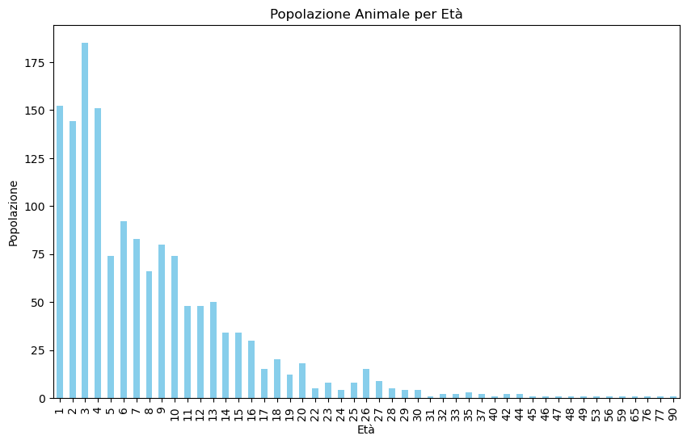

```python
età = df['Età']
distribuzione_età = età.value_counts().sort_index()
plt.figure(figsize=(10, 6))
distribuzione_età.plot(kind='bar', color='skyblue')
plt.title('Popolazione Animale per Età')
plt.xlabel('Età')
plt.ylabel('Popolazione')
plt.show()
```

Successivamente, il grafico seguente ci mostrerà la **Distribuzione dell'età degli animali nei parchi:**

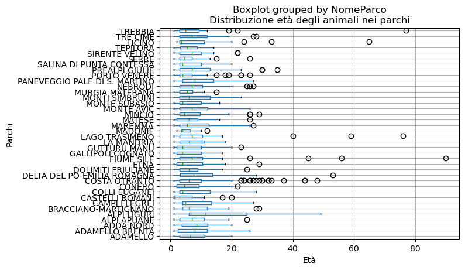

```python
plt.figure(figsize=(10, 6))
df.boxplot(column='Età', by='NomeParco', vert=False)
plt.title('Distribuzione età degli animali nei parchi')
plt.xlabel('Età')
plt.ylabel('Parchi')
plt.show()
```

### E' stata eseguita una breve EDA, sicuramente è possibile effettuare ancora altri studi e analisi univariate, bivariate e multivariate.